# Deep Learning and PyTorch

## 12/1/2022

print view

# Perceptron

[figure not shown]

$$output = \begin{cases} 0 \text{ if } w\cdot x + b \le 0 \\ 1 \text{ if } w\cdot x + b > 0 \end{cases}$$

# Perceptron

Consider the following perceptron:

[figure not shown]

If $x$ takes on only binary values, what are the possible outputs?

# Neurons

[figure not shown]

Instead of a *binary* output, we set the output to the result of an **activation function** $\sigma$

$$output = \sigma(w\cdot x + b)$$

# Activation Functions: Step (Perceptron)

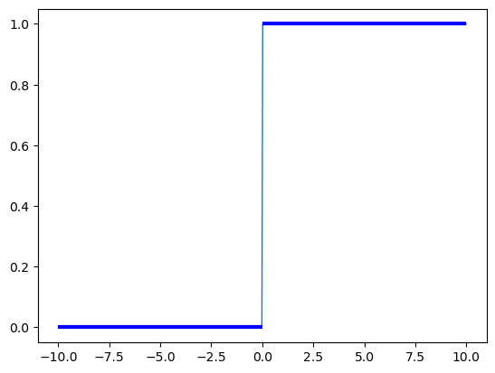

# Activation Functions: Sigmoid (Logistic)

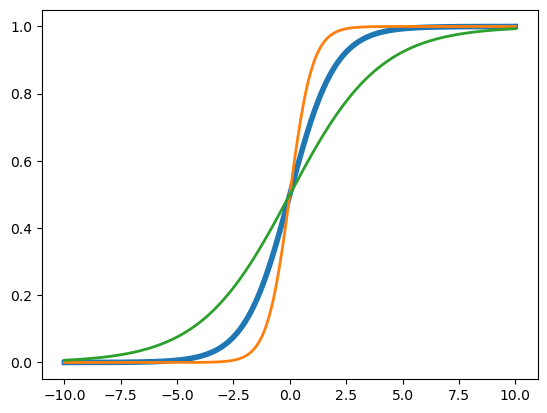

# Activation Functions: tanh

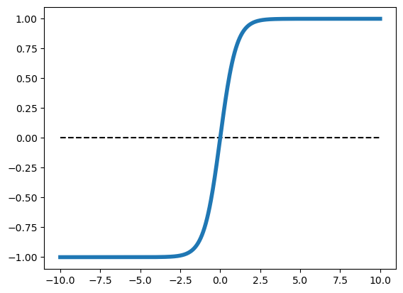

# Activation Functions: ReLU

Rectified Linear Unit: $\sigma(z) = \max(0,z)$

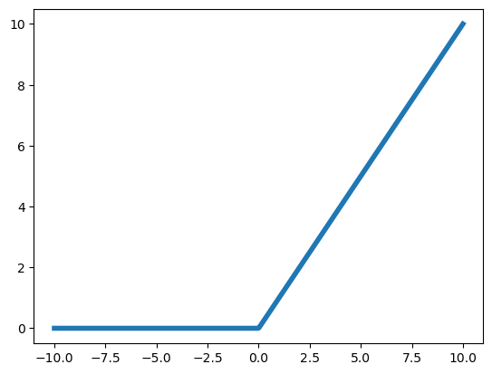

# Networks

[figure not shown]

Terminology alert: networks of neurons are sometimes called *multilayer perceptrons*, despite not using the step function.

# Networks

[figure not shown]

The number of input neurons corresponds to the number of features.

Layers are typically *fully connected*.

# Neural Networks

The [universal approximation theorem](https://en.wikipedia.org/wiki/Universal_approximation_theorem) says that, if some reasonable assumptions are made, a feedforward neural network with a finite number of nodes can approximate any continuous function to within a given error $\epsilon$ over a bounded input domain.

The theorem says nothing about the design (number of nodes/layers) of such a network.

The theorem says nothing about the *learnability* of the weights of such a network.

These are open theoretical questions.

Given a network design, how are we going to learn weights for the neurons?

# Stochastic Gradient Descent

[figure not shown]

Randomly select $m$ training examples $X_j$ and compute the gradient of the loss function ($L$). Update weights and biases with a given *learning rate* $\eta$. $$ w_k' = w_k-\frac{\eta}{m}\sum_j^m \frac{\partial L_{X_j}}{\partial w_k}$$ $$b_l' = b_l-\frac{\eta}{m} \sum_j^m \frac{\partial L_{X_j}}{\partial b_l} $$

Common loss functions: logistic, hinge, cross entropy, euclidean

# Loss Functions

[figure not shown]

x = 1 is a correct prediction, x = -1 a wrong prediction

# Backpropagation

Backpropagation is an efficient algorithm for computing the partial derivatives needed by the gradient descent update rule. For a training example $x$ and loss function $L$ in a network with $N$ layers:

1. **Feedforward**. For each layer $l$ compute $$a^{l} = \sigma(z^{l})$$ where $z$ is the weighted input and $a$ is the activation induced by $x$ (these are vectors representing all nodes of layer $l$).
2. **Compute output error** $$\delta^{N} = \nabla_a L \odot \sigma'(z^N)$$ where $ \nabla_a L_j = \partial L / \partial a^N_j$, the gradient of the loss with respect to the output activations. $\odot$ is the elementwise product.
3. **Backpropagate the error** $$\delta^{l} = ((w^{l+1})^T \delta^{l+1}) \odot \sigma'(z^{l})$$
4. **Calculate gradients** $$\frac{\partial L}{\partial w^l_{jk}} = a^{l-1}_k \delta^l_j \text{ and } \frac{\partial L}{\partial b^l_j} = \delta^l_j$$

## Backpropagation as the Chain Rule

$$\frac{\partial L}{\partial a^l} \cdot \frac{\partial a^l}{\partial z^l} \cdot \frac{\partial z^l}{\partial a^{l-1}} \cdot \frac{\partial a^{l-1}}{\partial z^{l-1}} \cdot \frac{\partial z^{l-1}}{\partial a^{l-2}} \cdots \frac{\partial a^{1}}{\partial z^{l}} \cdot \frac{\partial z^{l}}{\partial x} $$

# Deep Learning

[figure not shown]

A deep network is not more powerful (recall can approximate any function with a single layer), but may be more concise - can approximate some functions with many fewer nodes.

# Convolutional Neural Nets

[figure not shown]

Image recognition challenge results. Purple are deep learning methods.

# Convolution Filters

A filter applies a *convolution kernel* to an image.

The kernel is represented by an $n$x$n$ matrix where the target pixel is in the center.

The output of the filter is the sum of the products of the matrix elements with the corresponding pixels.

Examples from Wikipedia):

| Identity | Blur | Edge Detection |
| --- | --- | --- |

# Feature Maps

We can think of a kernel as identifying a *feature* in an image and the resulting image as a feature map that has high values (white) where the feature is present and low values (black) elsewhere.

*Feature maps retain the **spatial relationship** between features present in the original image.*

# Convolutional Layers

[figure not shown]

A single kernel is applied across the input. For each output feature map there is a single set of weights.

# Convolutional Layers

For images, each pixel is an input feature. Each hidden layer is a set of feature maps.

[figure not shown]

# Pooling

Pooling layers apply a fixed convolution (usually the non-linear MAX kernel). The kernel is usually applied with a *stride* to reduce the size of the layer.

- faster to train
- fewer parameters to fit
- less sensitive to small changes (MAX)

[figure not shown]

Consider an input image with 100 pixels. In a classic neural network, we hook these pixels up to a hidden layer with 10 nodes. In a CNN, we hook these pixels up to a convolutional layer with a 3x3 kernel and 10 output feature maps.

[figure not shown]

The last features maps are typically connected to one or more fully-connected layers to produce the desired output.

# [PyTorch](https://pytorch.org/)

PyTorch creates the dataflow graph implicitly as operations are performed.

- Dataflow graph can be parallelized
- Dataflow graph maintains **autograd** information - how to compute gradients for backpropagation
- Extremely flexible
- Easier to debug and develop than static approach

# PyTorch Tensors

Tensor is very similar to `numpy.array` in functionality.

- Is allocated to a device (CPU vs GPU)
- Potentially maintains autograd information

```
tensor([[0.8278, 0.9498, 0.5665, 0.3035],
        [0.4141, 0.8017, 0.0354, 0.1045],
        [0.7318, 0.3452, 0.8140, 0.3527]])
```

```
(torch.Size([3, 4]), torch.float32, device(type='cpu'), False)
```

# Modules vs Functional

**Modules** are objects that can be initialized with default parameters and store any learnable parameters. Learnable parameters can be easily extracted from the module (and any member modules). Modules are called as functions on their inputs.

**Functional** APIs maintain no state. All parameters are passed when the function is called.

# A network is a module

To define a network we create a module with submodules for operations with learnable parameters. Generally use functional API for operations without learnable parameters.

# MNIST

```
(<PIL.Image.Image image mode=L size=28x28>, 5)
```

Inputs need to be tensors...

```
tensor([[[0.0000, 0.0000, 0.0000, 0.0000, 0.0000, 0.0000, 0.0000, 0.0000,
          0.0000, 0.0000, 0.0000, 0.0000, 0.0000, 0.0000, 0.0000, 0.0000,
          0.0000, 0.0000, 0.0000, 0.0000, 0.0000, 0.0000, 0.0000, 0.0000,
          0.0000, 0.0000, 0.0000, 0.0000],
         [0.0000, 0.0000, 0.0000, 0.0000, 0.0000, 0.0000, 0.0000, 0.0000,
          0.0000, 0.0000, 0.0000, 0.0000, 0.0000, 0.0000, 0.0000, 0.0000,
          0.0000, 0.0000, 0.0000, 0.0000, 0.0000, 0.0000, 0.0000, 0.0000,
          0.0000, 0.0000, 0.0000, 0.0000],
         [0.0000, 0.0000, 0.0000, 0.0000, 0.0000, 0.0000, 0.0000, 0.0000,
          0.0000, 0.0000, 0.0000, 0.0000, 0.0000, 0.0000, 0.0000, 0.0000,
          0.0000, 0.0000, 0.0000, 0.0000, 0.0000, 0.0000, 0.0000, 0.0000,
          0.0000, 0.0000, 0.0000, 0.0000],
         [0.0000, 0.0000, 0.0000, 0.0000, 0.0000, 0.0000, 0.0000, 0.0000,
          0.0000, 0.0000, 0.0000, 0.0000, 0.0000, 0.0000, 0.0000, 0.0000,
          0.0000, 0.0000, 0.0000, 0.0000, 0.0000, 0.0000, 0.0000, 0.0000,
          0.0000, 0.0000, 0.0000, 0.0000],
         [0.0000, 0.0000, 0.0000, 0.0000, 0.0000, 0.0000, 0.0000, 0.0000,
          0.0000, 0.0000, 0.0000, 0.0000, 0.0000, 0.0000, 0.0000, 0.0000,
          0.0000, 0.0000, 0.0000, 0.0000, 0.0000, 0.0000, 0.0000, 0.0000,
          0.0000, 0.0000, 0.0000, 0.0000],
         [0.0000, 0.0000, 0.0000, 0.0000, 0.0000, 0.0000, 0.0000, 0.0000,
          0.0000, 0.0000, 0.0000, 0.0000, 0.0118, 0.0706, 0.0706, 0.0706,
          0.4941, 0.5333, 0.6863, 0.1020, 0.6510, 1.0000, 0.9686, 0.4980,
          0.0000, 0.0000, 0.0000, 0.0000],
         [0.0000, 0.0000, 0.0000, 0.0000, 0.0000, 0.0000, 0.0000, 0.0000,
          0.1176, 0.1412, 0.3686, 0.6039, 0.6667, 0.9922, 0.9922, 0.9922,
          0.9922, 0.9922, 0.8824, 0.6745, 0.9922, 0.9490, 0.7647, 0.2510,
          0.0000, 0.0000, 0.0000, 0.0000],
         [0.0000, 0.0000, 0.0000, 0.0000, 0.0000, 0.0000, 0.0000, 0.1922,
          0.9333, 0.9922, 0.9922, 0.9922, 0.9922, 0.9922, 0.9922, 0.9922,
          0.9922, 0.9843, 0.3647, 0.3216, 0.3216, 0.2196, 0.1529, 0.0000,
          0.0000, 0.0000, 0.0000, 0.0000],
         [0.0000, 0.0000, 0.0000, 0.0000, 0.0000, 0.0000, 0.0000, 0.0706,
          0.8588, 0.9922, 0.9922, 0.9922, 0.9922, 0.9922, 0.7765, 0.7137,
          0.9686, 0.9451, 0.0000, 0.0000, 0.0000, 0.0000, 0.0000, 0.0000,
          0.0000, 0.0000, 0.0000, 0.0000],
         [0.0000, 0.0000, 0.0000, 0.0000, 0.0000, 0.0000, 0.0000, 0.0000,
          0.3137, 0.6118, 0.4196, 0.9922, 0.9922, 0.8039, 0.0431, 0.0000,
          0.1686, 0.6039, 0.0000, 0.0000, 0.0000, 0.0000, 0.0000, 0.0000,
          0.0000, 0.0000, 0.0000, 0.0000],
```

[output cut: 57 more lines]

```
          0.8314, 0.5294, 0.5176, 0.0627, 0.0000, 0.0000, 0.0000, 0.0000,
          0.0000, 0.0000, 0.0000, 0.0000, 0.0000, 0.0000, 0.0000, 0.0000,
          0.0000, 0.0000, 0.0000, 0.0000],
         [0.0000, 0.0000, 0.0000, 0.0000, 0.0000, 0.0000, 0.0000, 0.0000,
          0.0000, 0.0000, 0.0000, 0.0000, 0.0000, 0.0000, 0.0000, 0.0000,
          0.0000, 0.0000, 0.0000, 0.0000, 0.0000, 0.0000, 0.0000, 0.0000,
          0.0000, 0.0000, 0.0000, 0.0000],
         [0.0000, 0.0000, 0.0000, 0.0000, 0.0000, 0.0000, 0.0000, 0.0000,
          0.0000, 0.0000, 0.0000, 0.0000, 0.0000, 0.0000, 0.0000, 0.0000,
          0.0000, 0.0000, 0.0000, 0.0000, 0.0000, 0.0000, 0.0000, 0.0000,
          0.0000, 0.0000, 0.0000, 0.0000],
         [0.0000, 0.0000, 0.0000, 0.0000, 0.0000, 0.0000, 0.0000, 0.0000,
          0.0000, 0.0000, 0.0000, 0.0000, 0.0000, 0.0000, 0.0000, 0.0000,
          0.0000, 0.0000, 0.0000, 0.0000, 0.0000, 0.0000, 0.0000, 0.0000,
          0.0000, 0.0000, 0.0000, 0.0000]]])
```

```
torch.Size([1, 28, 28])
```

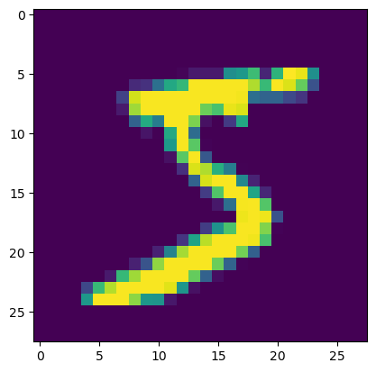

# Training MNIST

```
[tensor([[[[0., 0., 0.,  ..., 0., 0., 0.],
           [0., 0., 0.,  ..., 0., 0., 0.],
           [0., 0., 0.,  ..., 0., 0., 0.],
           ...,
           [0., 0., 0.,  ..., 0., 0., 0.],
           [0., 0., 0.,  ..., 0., 0., 0.],
           [0., 0., 0.,  ..., 0., 0., 0.]]],


         [[[0., 0., 0.,  ..., 0., 0., 0.],
           [0., 0., 0.,  ..., 0., 0., 0.],
           [0., 0., 0.,  ..., 0., 0., 0.],
           ...,
           [0., 0., 0.,  ..., 0., 0., 0.],
           [0., 0., 0.,  ..., 0., 0., 0.],
           [0., 0., 0.,  ..., 0., 0., 0.]]],


         [[[0., 0., 0.,  ..., 0., 0., 0.],
           [0., 0., 0.,  ..., 0., 0., 0.],
           [0., 0., 0.,  ..., 0., 0., 0.],
           ...,
           [0., 0., 0.,  ..., 0., 0., 0.],
           [0., 0., 0.,  ..., 0., 0., 0.],
           [0., 0., 0.,  ..., 0., 0., 0.]]],


         ...,


         [[[0., 0., 0.,  ..., 0., 0., 0.],
           [0., 0., 0.,  ..., 0., 0., 0.],
           [0., 0., 0.,  ..., 0., 0., 0.],
           ...,
           [0., 0., 0.,  ..., 0., 0., 0.],
           [0., 0., 0.,  ..., 0., 0., 0.],
           [0., 0., 0.,  ..., 0., 0., 0.]]],


         [[[0., 0., 0.,  ..., 0., 0., 0.],
           [0., 0., 0.,  ..., 0., 0., 0.],
           [0., 0., 0.,  ..., 0., 0., 0.],
           ...,
           [0., 0., 0.,  ..., 0., 0., 0.],
           [0., 0., 0.,  ..., 0., 0., 0.],
           [0., 0., 0.,  ..., 0., 0., 0.]]],


         [[[0., 0., 0.,  ..., 0., 0., 0.],
           [0., 0., 0.,  ..., 0., 0., 0.],
           [0., 0., 0.,  ..., 0., 0., 0.],
           ...,
           [0., 0., 0.,  ..., 0., 0., 0.],
           [0., 0., 0.,  ..., 0., 0., 0.],
           [0., 0., 0.,  ..., 0., 0., 0.]]]]),
 tensor([7, 3, 2, 8, 2, 8, 9, 0, 3, 1])]
```

```
tensor([[-0.0046,  0.0154,  0.0583, -0.0139,  0.0108,  0.0126,  0.0472, -0.0524,
         -0.1266, -0.0541],
        [ 0.0627,  0.0350, -0.0288,  0.0551,  0.0666,  0.0135,  0.0770, -0.1265,
         -0.1067, -0.0711],
        [ 0.0107, -0.0808, -0.0220,  0.1164,  0.0692,  0.0104,  0.0578, -0.0578,
         -0.0770, -0.1102],
        [ 0.0007, -0.0244, -0.0380,  0.1365,  0.0560,  0.0264,  0.0675, -0.0926,
         -0.0921, -0.0530],
        [ 0.0243, -0.0152,  0.0004,  0.0329,  0.1065, -0.0140,  0.0985, -0.0977,
         -0.0735, -0.0658],
        [ 0.0297,  0.0019, -0.0382,  0.1322,  0.0352,  0.0180,  0.1035, -0.0995,
         -0.0646, -0.0765],
        [-0.0226, -0.0480, -0.0361,  0.0404,  0.0097,  0.0148,  0.0399, -0.0366,
         -0.1430, -0.0075],
        [ 0.0740,  0.0156, -0.0477,  0.1097,  0.1008,  0.0111,  0.0768, -0.0905,
         -0.0431, -0.0928],
        [ 0.0595,  0.0201, -0.0897,  0.0976,  0.0733, -0.0140,  0.0782, -0.1178,
         -0.1070, -0.0730],
        [-0.0364, -0.0495, -0.0353,  0.0535,  0.0161,  0.0208,  0.0147, -0.0673,
         -0.0699, -0.0063]], device='cuda:0', grad_fn=<AddmmBackward0>)
```

# Training MNIST

Our network takes an image (as a tensor) and outputs class probabilities.

- Need a loss
- Need an optimizer (e.g. SGD, ADAM)
  - `backward` does *not* update parameters

```
tensor(2.3059, device='cuda:0', grad_fn=<NllLossBackward0>)
```

$$L(x,class) = - \log\left(\frac{e^{x_{\mathrm{class}}}}{\sum_j e^{x_j}}\right)$$

# Training MNIST

**Epoch** - One pass through the training data.

```
CPU times: user 5min, sys: 25.4 s, total: 5min 26s
Wall time: 6min 39s
```

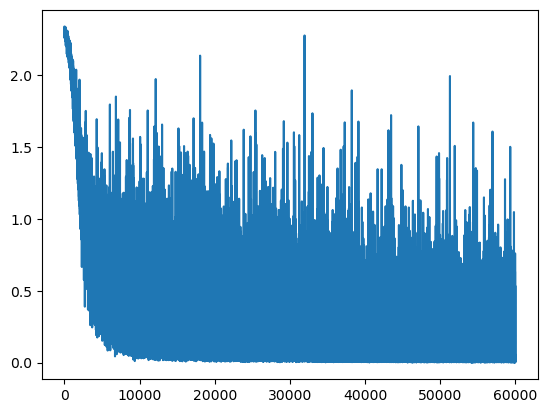

This is the **batch loss**.

# Testing MNIST

```
Accuracy 0.9703
```

# Some Failures

*Not from this particular network

[figure not shown]

Top label is correct. Bottom is prediction from a CNN.

# Generative vs. Discriminative

A *generative* model produces as output the input of a discriminative model: $P(X|Y=y)$ *or* $P(X,Y)$

$y \rightarrow$

Model

$ \rightarrow X$

Model

$ \rightarrow X,y$

# Autoencoders

A neural network trained to generate its input.

[figure not shown]

https://en.wikipedia.org/wiki/Autoencoder

# Latent Space

http://blog.fastforwardlabs.com/2016/08/12/introducing-variational-autoencoders-in-prose-and.html

[figure not shown]

# Latent Space Arithmetic

https://arxiv.org/pdf/1707.05776.pdf

[figure not shown]

# Latent Spaces for Molecules

https://arxiv.org/abs/1610.02415

| 1% - 70% of output valid SMILES |  |
| --- | --- |

# Generative Models of the Cell

https://arxiv.org/pdf/1705.00092.pdf

https://drive.google.com/file/d/0B2tsfjLgpFVhMnhwUVVuQnJxZTg/view

# Generative Adversarial Networks

https://arxiv.org/abs/1406.2661

[figure not shown]

https://youtu.be/G06dEcZ-QTg

https://thispersondoesnotexist.com

[figure not shown]

# pix2pix

[figure not shown]

https://affinelayer.com/pixsrv/

https://github.com/junyanz/pytorch-CycleGAN-and-pix2pix

# CycleGAN

https://medium.com/coding-blocks/introduction-to-cyclegans-1dbdb8fbe781

[figure not shown]

https://techcrunch.com/2018/12/31/this-clever-ai-hid-data-from-its-creators-to-cheat-at-its-appointed-task/

[figure not shown]

## Deep learning is not profound learning.

But it is quite powerful and flexible.